# HW 6

Liam Middleton

2023-03-29

## This dataset contains estimates of the percentage of body fat determined by underwater weighing and various body circumference measurements for 252 men.

```r
#adapt this  code to your working directory
setwd("C:/Users/liamm/OneDrive/Documents/DATA 1501/Assignment 6")
bf <- read.csv("C:/Users/liamm/OneDrive/Documents/DATA 1501/Assignment 6/BodyFat.csv", header = TRUE, sep = ",")
head(bf)
```

```
##   Density BodyFat Age Weight Height Neck Chest Abdomen   Hip Thigh Knee Ankle
## 1  1.0708    12.3  23 154.25  67.75 36.2  93.1    85.2  94.5  59.0 37.3  21.9
## 2  1.0853     6.1  22 173.25  72.25 38.5  93.6    83.0  98.7  58.7 37.3  23.4
## 3  1.0414    25.3  22 154.00  66.25 34.0  95.8    87.9  99.2  59.6 38.9  24.0
## 4  1.0751    10.4  26 184.75  72.25 37.4 101.8    86.4 101.2  60.1 37.3  22.8
## 5  1.0340    28.7  24 184.25  71.25 34.4  97.3   100.0 101.9  63.2 42.2  24.0
## 6  1.0502    20.9  24 210.25  74.75 39.0 104.5    94.4 107.8  66.0 42.0  25.6
##   Biceps Forearm Wrist
## 1   32.0    27.4  17.1
## 2   30.5    28.9  18.2
## 3   28.8    25.2  16.6
## 4   32.4    29.4  18.2
## 5   32.2    27.7  17.7
## 6   35.7    30.6  18.8
```

### Problem 1. Consider the variables Weight, Chest, Abdomen, Thigh, Hip, and Biceps. Which of these variables shows the strongest correlation to body fat? Which one shows the weakest correlation to body fat? Hint: Compute the Pearson correlation coefficient between each of these variables and BodyFat.

```r
setwd("C:/Users/liamm/OneDrive/Documents/DATA 1501/Assignment 6")
bf <- read.csv("C:/Users/liamm/OneDrive/Documents/DATA 1501/Assignment 6/BodyFat.csv", header = TRUE, sep = ",")
head(bf)
```

```
##   Density BodyFat Age Weight Height Neck Chest Abdomen   Hip Thigh Knee Ankle
## 1  1.0708    12.3  23 154.25  67.75 36.2  93.1    85.2  94.5  59.0 37.3  21.9
## 2  1.0853     6.1  22 173.25  72.25 38.5  93.6    83.0  98.7  58.7 37.3  23.4
## 3  1.0414    25.3  22 154.00  66.25 34.0  95.8    87.9  99.2  59.6 38.9  24.0
## 4  1.0751    10.4  26 184.75  72.25 37.4 101.8    86.4 101.2  60.1 37.3  22.8
## 5  1.0340    28.7  24 184.25  71.25 34.4  97.3   100.0 101.9  63.2 42.2  24.0
## 6  1.0502    20.9  24 210.25  74.75 39.0 104.5    94.4 107.8  66.0 42.0  25.6
##   Biceps Forearm Wrist
## 1   32.0    27.4  17.1
## 2   30.5    28.9  18.2
## 3   28.8    25.2  16.6
## 4   32.4    29.4  18.2
## 5   32.2    27.7  17.7
## 6   35.7    30.6  18.8
```

```r
cor(bf$Weight, bf$BodyFat, method = "pearson")
```

```
## [1] 0.612414
```

```r
cor(bf$Chest, bf$BodyFat, method = "pearson")
```

```
## [1] 0.7026203
```

```r
cor(bf$Abdomen, bf$BodyFat, method = "pearson")
```

```
## [1] 0.8134323
```

```r
cor(bf$Thigh, bf$BodyFat, method = "pearson")
```

```
## [1] 0.5596075
```

```r
cor(bf$Hip, bf$BodyFat, method = "pearson")
```

```
## [1] 0.6252009
```

```r
cor(bf$Biceps, bf$BodyFat, method = "pearson")
```

```
## [1] 0.4932711
```

```r
print("the vairable with the strongest correlation is Abdomen. The variable with the weakest correlation is Biceps.")
```

```
## [1] "the vairable with the strongest correlation is Abdomen. The variable with the weakest correlation is Biceps."
```

### Problem 2. Make a scatterplot of BodyFat versus each of the two variables that were the answer to problem 1. There should be two scatterplots here.

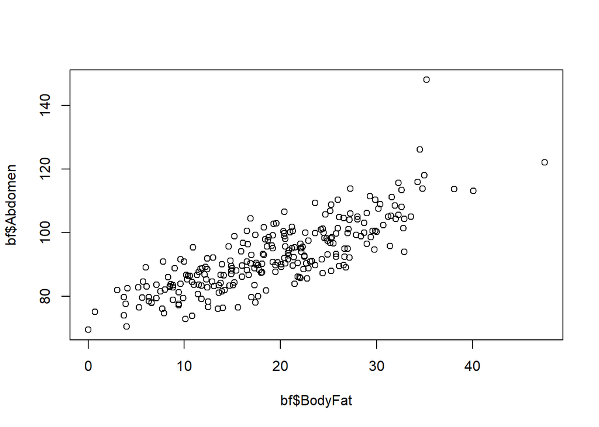

```r
#Your code and answer goes here
plot(bf$BodyFat, bf$Abdomen)
```

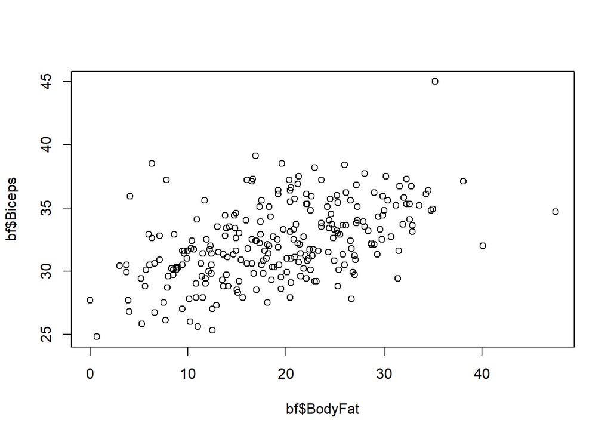

```r
plot(bf$BodyFat, bf$Biceps)
```